# Word vectors and embeddings 1

## Introduction

The hands-on exercise for this week focuses on word embedding and provides an overview of the data structures, and functions relevant for, estimating word vectors for word-embedding analyses.

In this tutorial, you will learn how to:

- Generate word vectors (embeddings) via SVD
- Train a local word embedding model in GloVe
- Visualize and inspect results
- Load and examine pre-trained embeddings

Note: Adapts from tutorials by Chris Bail [here](https://cbail.github.io/textasdata/word2vec/rmarkdown/word2vec.html) and Julia Silge [here](https://juliasilge.com/blog/tidy-word-vectors/) and Emil Hvitfeldt and Julia Silge [here](https://smltar.com/).

## Setup

```r
library(tidyverse) # loads dplyr, ggplot2, and others
library(stringr) # to handle text elements
library(tidytext) # includes set of functions useful for manipulating text
library(ggthemes) # to make your plots look nice
library(quanteda) # for transforming and tokenizing text
library(text2vec) # for word embedding implementation
library(widyr) # for reshaping the text data
library(irlba) # for svd
```

We begin by reading in the data. These data come from a sample of 1m tweets by elected UK MPs over the period 2017-2019. The data contain just the name of the MP-user, the text of the tweet, and the MP’s party. We then just add an ID variable called “postID.”

```r
twts_sample <- readRDS("twts_corpus_sample.rds")

#create tweet id
twts_sample$postID <- row.names(twts_sample)
```

If you’re working on this document from your own computer (“locally”) you can download the tweets sample data in the following way:

```r
twts_sample <- readRDS(gzcon(url("https://github.com/cjbarrie/wordvectutorial/blob/main/data/wordembed/twts_corpus_sample.rds?raw=true")))
```

## Word vectors via SVD

We’re going to set about generating a set of word vectors with from our text data. Note that many word embedding applications will use pre-trained embeddings from a much larger corpus, or will generate local embeddings using neural net-based approaches.

Here, we’re instead going to generate a set of embeddings or word vectors by making a series of calculations based on the frequencies with which words appear in different contexts. We will then use a technique called the “Singular Value Decomposition” (SVD). This is a dimensionality reduction technique where the first axis of the resulting composition is designed to capture the most variance, the second the second-most etc…

How do we achieve this?

## Implementation

The first thing we need to do is to get our data in the right format to calculate so-called “skip-gram probabilties.” If you go through the code line by the line in the below you will begin to understand what these are.

What’s going on?

Well, we’re first unnesting our tweet data as in previous exercises. But importantly, here, we’re not unnesting to individual tokens but to ngrams of length 6 or, in other words, for postID n with words k indexed by i, we take words i<sub>1</sub> …i<sub>6</sub>, then we take words i<sub>2</sub> …i<sub>7</sub>. Try just running the first two lines of the code below to see what this means in practice.

After this, we make a unique ID for the particular ngram we create for each postID, and then we make a unique skipgramID for each postID and ngram. And then we unnest the words of each ngram associated with each skipgramID.

You can see the resulting output below.

```r
#create context window with length 6
tidy_skipgrams <- twts_sample %>%
    unnest_tokens(ngram, tweet, token = "ngrams", n = 6) %>%
    mutate(ngramID = row_number()) %>%
    tidyr::unite(skipgramID, postID, ngramID) %>%
    unnest_tokens(word, ngram)

head(tidy_skipgrams, n=20)
```

```
## # A tibble: 20 × 4
##    username  party_value             skipgramID word
##    <chr>     <chr>                   <chr>      <chr>
##  1 kirstysnp Scottish National Party 1_1        in
##  2 kirstysnp Scottish National Party 1_1        amongst
##  3 kirstysnp Scottish National Party 1_1        all
##  4 kirstysnp Scottish National Party 1_1        the
##  5 kirstysnp Scottish National Party 1_1        horror
##  6 kirstysnp Scottish National Party 1_1        at
##  7 kirstysnp Scottish National Party 1_2        amongst
##  8 kirstysnp Scottish National Party 1_2        all
##  9 kirstysnp Scottish National Party 1_2        the
## 10 kirstysnp Scottish National Party 1_2        horror
## 11 kirstysnp Scottish National Party 1_2        at
## 12 kirstysnp Scottish National Party 1_2        the
## 13 kirstysnp Scottish National Party 1_3        all
## 14 kirstysnp Scottish National Party 1_3        the
## 15 kirstysnp Scottish National Party 1_3        horror
## 16 kirstysnp Scottish National Party 1_3        at
## 17 kirstysnp Scottish National Party 1_3        the
## 18 kirstysnp Scottish National Party 1_3        notion
## 19 kirstysnp Scottish National Party 1_4        the
## 20 kirstysnp Scottish National Party 1_4        horror
```

What next?

Well we can now calculate a set of probabilities from our skipgrams. We do so with the `pairwise_count()` function from the `widyr` package. Essentially, this function is saying: for each skipgramID count the number of times a word appears with another word for that feature (where the feature is the skipgramID). We set `diag` to `TRUE` when we also want to count the number of times a word appears near itself.

The probability we are then calculating is the number of times a word appears with another word denominated by the total number of word pairings across the whole corpus.

```r
#calculate probabilities
skipgram_probs <- tidy_skipgrams %>%
    pairwise_count(word, skipgramID, diag = TRUE, sort = TRUE) %>% # diag = T means that we also count when the word appears twice within the window
    mutate(p = n / sum(n))

head(skipgram_probs[1000:1020,], n=20)
```

```
## # A tibble: 20 × 4
##    item1   item2       n         p
##    <chr>   <chr>   <dbl>     <dbl>
##  1 no      to       4100 0.0000531
##  2 vote    for      4099 0.0000531
##  3 for     vote     4099 0.0000531
##  4 see     the      4078 0.0000528
##  5 the     see      4078 0.0000528
##  6 having  having   4076 0.0000528
##  7 by      of       4065 0.0000527
##  8 of      by       4065 0.0000527
##  9 this    with     4051 0.0000525
## 10 with    this     4051 0.0000525
## 11 set     set      4050 0.0000525
## 12 right   the      4045 0.0000524
## 13 the     right    4045 0.0000524
## 14 what    the      4044 0.0000524
## 15 going   to       4044 0.0000524
## 16 the     what     4044 0.0000524
## 17 to      going    4044 0.0000524
## 18 evening evening  4035 0.0000523
## 19 get     the      4032 0.0000522
## 20 the     get      4032 0.0000522
```

So we see, for example, the words vote and for appear 4099 times together. Denominating that by the total n of word pairings (or `sum(skipgram_probs$n)`), gives us our probability p.

Okay, now we have our skipgram probabilities we need to get our “unigram probabilities” in order to normalize the skipgram probabilities before applying the singular value decomposition.

What is a “unigram probability”? Well, this is just a technical way of saying: count up all the appearances of a given word in our corpus then divide that by the total number of words in our corpus. And we can do this as such:

```r
#calculate unigram probabilities (used to normalize skipgram probabilities later)
unigram_probs <- twts_sample %>%
    unnest_tokens(word, tweet) %>%
    count(word, sort = TRUE) %>%
    mutate(p = n / sum(n))
```

Finally, it’s time to normalize our skipgram probabilities.

We take our skipgram probabilities, we filter out word pairings that appear twenty times or less. We rename our words “item1” and “item2,” we merge in the unigram probabilities for both words.

And then we calculate the joint probability as the skipgram probability divided by the unigram probability for the first word in the pairing divided by the unigram probability for the second word in the pairing. This is equivalent to: P(x,y)/P(x)P(y).

In essence, the interpretation of this value is: *“do events (words) x and y occur together more often than we would expect if they were independent”*?

Once we’ve recovered these normalized probabilities, we can have a look at the joint probabilities for a given item, i.e., word. Here, we look at the word “brexit” and look at those words with the highest value for “p_together.”

Higher values greater than 1 indicate that the words are more likely to appear close to each other; low values less than 1 indicate that they are unlikely to appear close to each other. This, in other words, gives an indication of the association of two words.

```r
#normalize skipgram probabilities
normalized_prob <- skipgram_probs %>%
    filter(n > 20) %>% #filter out skipgrams with n <=20
    rename(word1 = item1, word2 = item2) %>%
    left_join(unigram_probs %>%
                  select(word1 = word, p1 = p),
              by = "word1") %>%
    left_join(unigram_probs %>%
                  select(word2 = word, p2 = p),
              by = "word2") %>%
    mutate(p_together = p / p1 / p2)

normalized_prob %>%
    filter(word1 == "brexit") %>%
    arrange(-p_together)
```

```
## # A tibble: 1,016 × 7
##    word1  word2                      n           p      p1         p2 p_together
##    <chr>  <chr>                  <dbl>       <dbl>   <dbl>      <dbl>      <dbl>
##  1 brexit scotlandsplaceineurope    37 0.000000479 0.00278 0.00000186       92.6
##  2 brexit preparedness              22 0.000000285 0.00278 0.00000149       68.8
##  3 brexit dividend                 176 0.00000228  0.00278 0.0000127        64.8
##  4 brexit brexit                 38517 0.000499    0.00278 0.00278          64.6
##  5 brexit softer                    50 0.000000648 0.00278 0.00000410       56.9
##  6 brexit botched                  129 0.00000167  0.00278 0.0000153        39.4
##  7 brexit impasse                   53 0.000000687 0.00278 0.00000820       30.1
##  8 brexit smooth                    30 0.000000389 0.00278 0.00000596       23.5
##  9 brexit frustrate                 28 0.000000363 0.00278 0.00000559       23.4
## 10 brexit deadlock                 120 0.00000155  0.00278 0.0000246        22.8
## # ℹ 1,006 more rows
```

Using this normalized probabilities, we then calculate the PMI or “Pointwise Mutual Information” value, which is simply the log of the joint probability we calculated above.

**Definition time**: “PMI is logarithm of the probability of finding two words together, normalized for the probability of finding each of the words alone.”

We then cast our word pairs into a sparse matrix where values correspond to the PMI between two corresponding words.

```r
pmi_matrix <- normalized_prob %>%
    mutate(pmi = log10(p_together)) %>%
    cast_sparse(word1, word2, pmi)

#remove missing data
pmi_matrix@x[is.na(pmi_matrix@x)] <- 0
#run SVD
pmi_svd <- irlba(pmi_matrix, 256, maxit = 500)

glimpse(pmi_matrix)
```

```
## Formal class 'dgCMatrix' [package "Matrix"] with 6 slots
##   ..@ i       : int [1:350700] 0 1 2 3 4 5 6 7 8 9 ...
##   ..@ p       : int [1:21173] 0 7819 14360 20175 25467 29910 34368 39207 43376 46401 ...
##   ..@ Dim     : int [1:2] 21172 21172
##   ..@ Dimnames:List of 2
##   .. ..$ : chr [1:21172] "the" "to" "and" "of" ...
##   .. ..$ : chr [1:21172] "the" "to" "and" "of" ...
##   ..@ x       : num [1:350700] 0.65173 -0.01915 -0.00911 0.26937 -0.52456 ...
##   ..@ factors : list()
```

Notice here that we are setting the vector size to equal 256. This just means that we have a vector length of 256 for any given word.

That is, the set of numbers used to represent a word has length limited to 256. This is arbitrary and can be changed. Typically, a size in the low hundreds is chosen when representing a word as a vector.

The word vectors are then taken as the “u” column, or the left-singular vectors, of the SVD.

```r
#next we output the word vectors:
word_vectors <- pmi_svd$u
rownames(word_vectors) <- rownames(pmi_matrix)

dim(word_vectors)
```

```
## [1] 21172   256
```

## Exploration

We can define a simple function below to then take our word vector, and find the most similar words, or nearest neighbours, for a given word:

```r
nearest_words <- function(word_vectors, word){
  selected_vector = word_vectors[word,]
  mult = as.data.frame(word_vectors %*% selected_vector) #dot product of selected word vector and all word vectors

  mult %>%
  rownames_to_column() %>%
  rename(word = rowname,
         similarity = V1) %>%
    anti_join(get_stopwords(language = "en")) %>%
  arrange(-similarity)

}

boris_synonyms <- nearest_words(word_vectors, "boris")
brexit_synonyms <- nearest_words(word_vectors, "brexit")
head(boris_synonyms, n=10)
```

```
##       word similarity
## 1  johnson 0.10309556
## 2    boris 0.09940448
## 3   jeremy 0.04823204
## 4    trust 0.04800155
## 5   corbyn 0.04102031
## 6   farage 0.03973588
## 7    trump 0.03938184
## 8    can.t 0.03533624
## 9     says 0.03324624
## 10    word 0.03267437
```

```r
head(brexit_synonyms, n=10)
```

```
##        word similarity
## 1    brexit 0.38737979
## 2      deal 0.15083433
## 3   botched 0.05003683
## 4      tory 0.04377030
## 5   unleash 0.04233445
## 6    impact 0.04139872
## 7   theresa 0.04017608
## 8  approach 0.03970233
## 9  handling 0.03901461
## 10  orderly 0.03897535
```

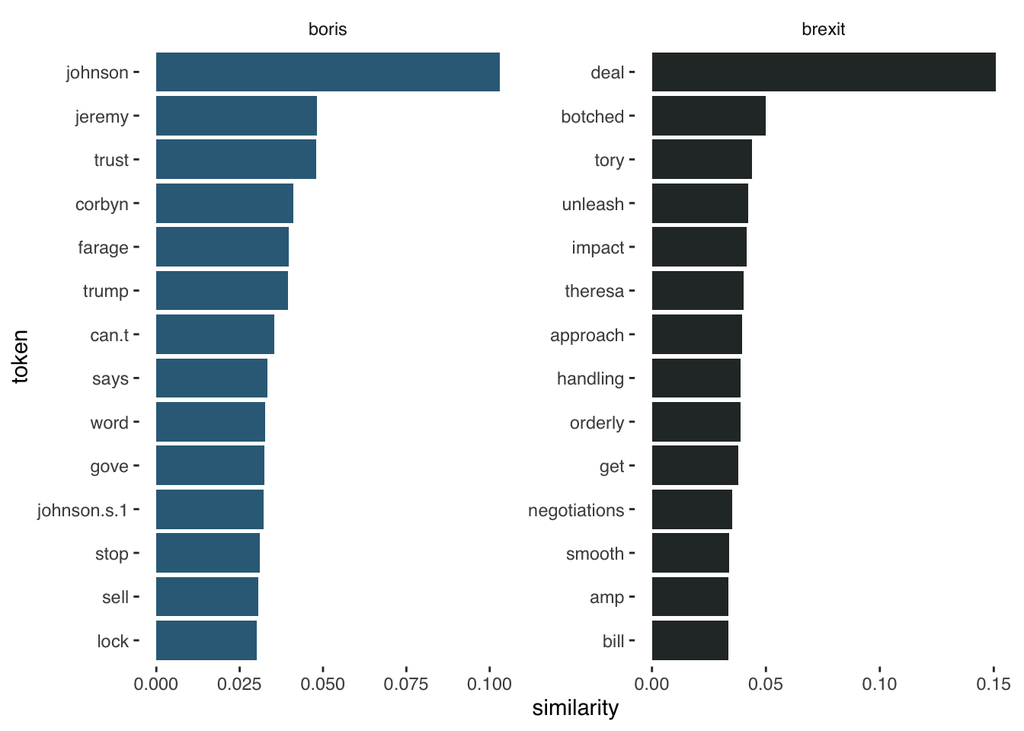

```r
#then we can visualize
brexit_synonyms %>%
  mutate(selected = "brexit") %>%
  bind_rows(boris_synonyms %>%
              mutate(selected = "boris")) %>%
  group_by(selected) %>%
  top_n(15, similarity) %>%
  mutate(token = reorder(word, similarity)) %>%
  filter(token!=selected) %>%
  ggplot(aes(token, similarity, fill = selected)) +
  geom_col(show.legend = FALSE) +
  facet_wrap(~selected, scales = "free") +
  scale_fill_manual(values = c("#336B87", "#2A3132")) +
  coord_flip() +
  theme_tufte(base_family = "Helvetica")
```

## GloVe Embeddings

This section adapts from tutorials by Pedro Rodriguez [here](https://github.com/prodriguezsosa/conText/blob/master/vignettes/quickstart_local_transform.md) and Dmitriy Selivanov [here](http://text2vec.org/glove.html) and Wouter van Gils [here](https://medium.com/broadhorizon-cmotions/nlp-with-r-part-2-training-word-embedding-models-and-visualize-results-ae444043e234).

## GloVe algorithm

This section is taken from `text2vec` package page [here](http://text2vec.org/glove.html).

The GloVe algorithm by Pennington, Socher, and Manning (2014) consists of the following steps:

1. Collect word co-occurence statistics in a form of word co-ocurrence matrix $X$. Each element $X_{ij}$ of such matrix represents how often word *i* appears in context of word *j*. Usually we scan our corpus in the following manner: for each term we look for context terms within some area defined by a *window_size* before the term and a *window_size* after the term. Also we give less weight for more distant words, usually using this formula:
   $$decay = 1/offset$$
2. Define soft constraints for each word pair:
   $$w_i^Tw_j + b_i + b_j = log(X_{ij})$$
   Here $w_i$ - vector for the main word, $w_j$ - vector for the context word, $b_i$, $b_j$ are scalar biases for the main and context words.
3. Define a cost function
   $$J =
   \sum_{i=1}^V \sum_{j=1}^V \; f(X_{ij}) ( w_i^T w_j + b_i + b_j - \log
   X_{ij})^2$$
   Here $f$ is a weighting function which help us to prevent learning only from extremely common word pairs. The GloVe authors choose the following function:

$$f(X_{ij}) =
\begin{cases}
(\frac{X_{ij}}{x_{max}})^\alpha & \text{if } X_{ij} < XMAX \\
1 & \text{otherwise}
\end{cases}$$

How do we go about implementing this algorithm in R?

Let’s first make sure we have loaded the packages we need:

```r
library(text2vec) # for implementation of GloVe algorithm
library(stringr) # to handle text strings
library(umap) # for dimensionality reduction later on
```

## Implementation

We then need to set some of the choice parameters of the GloVe model. The first is the window size `WINDOW_SIZE`, which, as above, is arbitrary but normally set around 6-8. This means we are looking for word context of words up to 6 words around the target word. The image below illustrates this choice parameter for the word “cat” in a given sentence, with increase context window size:

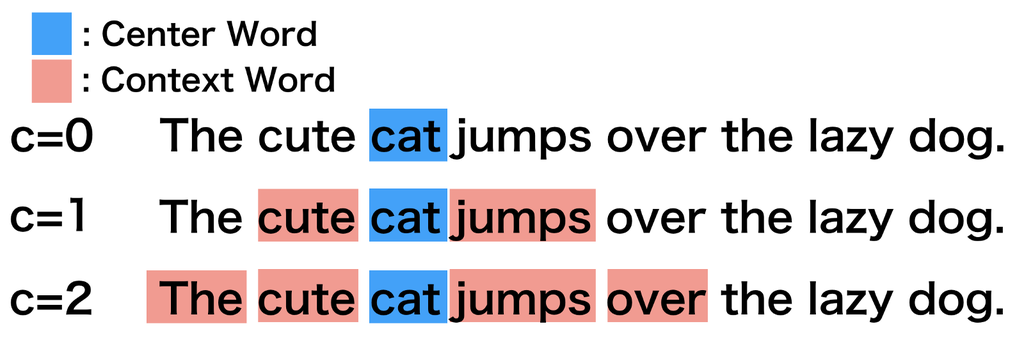

Context window

And this will ultimately be understood in matrix format as:

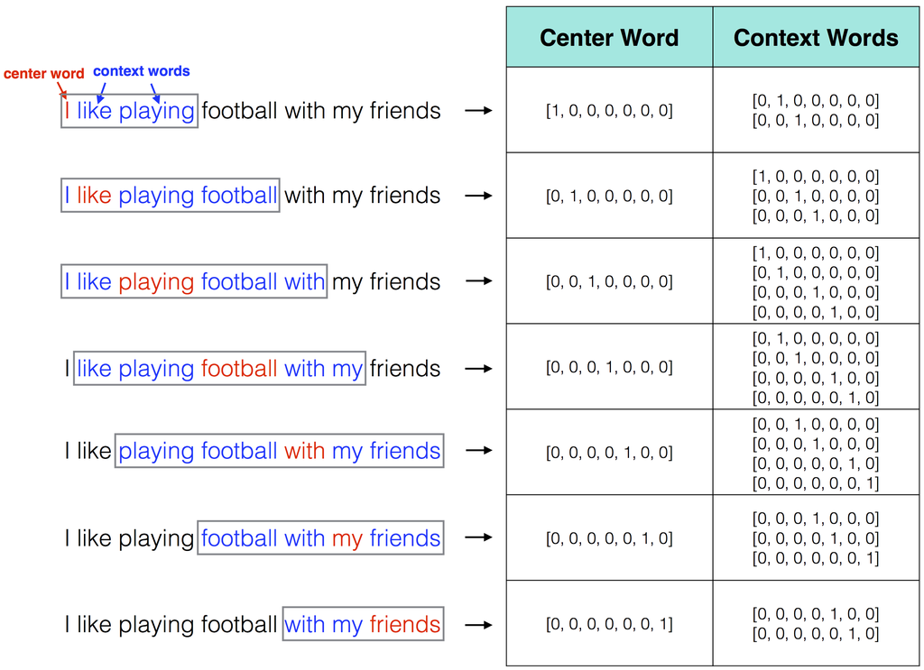

Context window

The iterations parameter `ITERS` simply sets the maximum number of iterations to allow for model convergence. This number of iterations is relatively high and the model will likely converge before 100 iterations.

```r
# ================================ choice parameters
# ================================
WINDOW_SIZE <- 6
DIM <- 300
ITERS <- 100
```

We then create a corpus object with the `quanteda` package. This is just the type of object that is we need in order to tokenize and reformat the text.

After this, we create the vocabulary object needed to implement the GloVe algorithm. We do this by using the `toks()` function from the same `quanteda` package.

```r
twts_corpus <- corpus(twts_sample, text_field = "tweet")
toks <- tokens(twts_corpus)
```

Next up we create out document feature matrix. This is a matrix where each row represents a the feature count for a given document (tweet); i.e., the number of times a given word appears in that document.

We can also take the “top_feats” by specifying the number of features (i.e., unique terms) we want there to be in our resulting vocabulary.

Here, I have not pruned the vocabulary at all. But you can see the code you would use if you wanted do this hashed out.

```r
# Get top k features
combined_dfm <- dfm(toks, verbose = TRUE)
top_feats <- featnames(combined_dfm)

# top_feats <- dfm(toks) %>%
#   dfm_trim(min_termfreq = 5)%>%
#   featnames()

# leave the pads so that non-adjacent words will not become adjacent
toks_feats <- tokens_select(toks, top_feats, padding = TRUE)
```

The final step before estimating our word embedding is then to construct our co-occurrence matrix as follows:

```r
# Construct the feature co-occurrence matrix
toks_fcm <- fcm(
  toks_feats,
  context = "window",
  window = WINDOW_SIZE,
  count = "frequency",
  tri = FALSE,
  weights = rep(1, WINDOW_SIZE)
)
```

Finally, we estimate the word embedding and save it as a .rds file.

```r
glove <- GlobalVectors$new(rank = DIM, x_max = 100, learning_rate = 0.05)
wv_main <- glove$fit_transform(
  toks_fcm,
  n_iter = ITERS,
  convergence_tol = 1e-3,
  n_threads = parallel::detectCores()
)
wv_context <- glove$components
glove_embedding <- wv_main + t(wv_context)

saveRDS(glove_embedding, file = "local_glove.rds")
```

**To save time when working through this tutorial, you may also download the resulting embedding from the Github repo with**:

```r
url <- "https://github.com/cjbarrie/wordvectutorial/blob/main/data/wordembed/local_glove.rds?raw=true"
glove_embedding <- readRDS(url(url, method="libcurl"))
```

## Validation

How do we check whether our embedding actually makes sense?

Well, a first stop is to look at the nearest neighbours of words and determine if they correspond to our own understandings of what constitutes a semantically related word.

```r
word <- glove_embedding["economy",, drop = FALSE]
cos_sim = sim2(x = glove_embedding, y = word, method = "cosine", norm = "l2")
select <- data.frame(rownames(as.data.frame(head(sort(cos_sim[,1], decreasing = TRUE), 25))))
colnames(select) <- "word"
select
```

```
##           word
## 1      economy
## 2         jobs
## 3        works
## 4           UK
## 5       create
## 6      country
## 7     building
## 8       strong
## 9      British
## 10    industry
## 11     Britain
## 12        that
## 13         our
## 14       build
## 15       jobs,
## 16      global
## 17      growth
## 18         the
## 19    economic
## 20          we
## 21 communities
## 22         its
## 23  businesses
## 24         and
## 25          is
```

```r
write.csv(glove_embedding, "glove_embedding.csv", row.names = TRUE)
```

In order to visualize your own embeddings in 3D, you can use a tool like Python’s `tensorboard`. The bonus materials in “2-visualize_embeddings.py” walk you through how to achieve that.

Alternatively, you can visit [here](https://projector.tensorflow.org/) to see an example of one of these 3D projections. You can download the embedding you will need (too big for Github) [here](https://www.dropbox.com/scl/fi/y0u3qwem1yxno1lxmjq2r/glove_embedding.csv?rlkey=00vxah2lz4l7qj5n3edk9t0t2&dl=0).

## Exercises

1. Inspect and visualize the nearest neighbour synonyms of other relevant words in the tweets corpus
2. Identify another region of interest in the GloVe-trained model and visualize

Pennington, Jeffrey, Richard Socher, and Christopher Manning. 2014. “GloVe: Global Vectors for Word Representation.” In, 15321543. Doha, Qatar: Association for Computational Linguistics. https://doi.org/10.3115/v1/D14-1162.